# HMM search output analyses

Executing HMM search output analyses with max e-val:s

LJM

2020-01-20

This document contains the final analyses and visualialisations of HMMer search with eggNOG viral HMM profiles on fOTUs.

# 1 Load libraries

```r
library(tidyverse)
#library(devtools)
#install_github("vqv/ggbiplot")
library(ggbiplot)
#install.packages("vegan")
library(vegan)
```

# 2 Read intermediary `csv` file

In the intermediary `csv` file the $-log_{10}(\text{e-val})$:s are the maximum e-values among all the hits to the fOTUs instead (and in contrast to the previous run in file `2019-11-25_hmmsearch_output_analyses.Rmd`) of the average of all the HMMsearch hits to the fOTUs.

```r
columns <- paste("c", strrep("d",8315), sep = "")
fOTUsHMM <- read_csv(file = "../analyses/HMMsearch/max_fOTUsHMM.csv", col_types = columns)
```

# 3 Exchange NA, Inf and -Inf with 0

```r
is.na(fOTUsHMM) <- sapply(fOTUsHMM, is.infinite)
fOTUsHMM[is.na(fOTUsHMM)] <- 0
```

# 4 Move fOTU names to row names and execute PCA

```r
fOTUsHMM_pca <- fOTUsHMM %>%
  column_to_rownames(var = "fOTU_name") %>%
  prcomp(.,
         center = TRUE)
```

# 5 Visualise the results

## 5.1 PCA plots

But before starting to draw any figures, let’s define some plot variables which will be used for all the plots.

```r
plot_title_justification <- 0.5
figure_width      <- 1000
figure_height     <- 750
plot_title_size   <- 22
axis_title_size   <- 18
axis_text_size    <- 16
plot_resolution   <- 320
legend_text_size  <- 16
legend_title_size <- 18
```

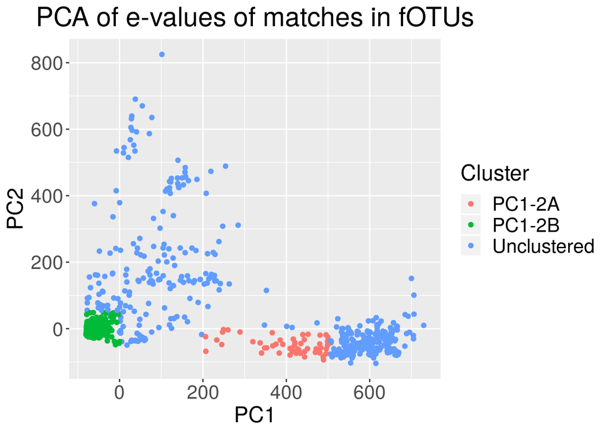

```r
PC12s <- tibble(fOTUs = names(fOTUsHMM_pca$x[,1]),
              PC1 = unname(fOTUsHMM_pca$x[,1]),
              PC2 = unname(fOTUsHMM_pca$x[,2]),
              ) %>%
  mutate(Cluster = case_when(PC1 >= -100 & PC1 <= 0   & PC2 >= -50  & PC2 <= 50 ~ 'PC1-2B',
                             PC1 >=  200 & PC1 <= 500 & PC2 >= -100 & PC2 <= 0 ~ 'PC1-2A',
                             TRUE ~ 'Unclustered')) %>%
  mutate_at(4, as.factor)

title <- "PCA of e-values of matches in fOTUs"
qplot(PC1,
      PC2,
      data = PC12s,
      geom = c("point"),
      group = Cluster,
      color = Cluster,
      fill = Cluster) + ggtitle(title) +
  theme(plot.title = element_text(hjust = plot_title_justification,
                                  size  = plot_title_size),
        axis.title=element_text(  size  = axis_title_size)) +
  theme(legend.text=element_text( size  = legend_text_size)) +
  theme(legend.title=element_text(size  = legend_title_size)) +
  theme(axis.text=element_text(   size  = axis_text_size))
```

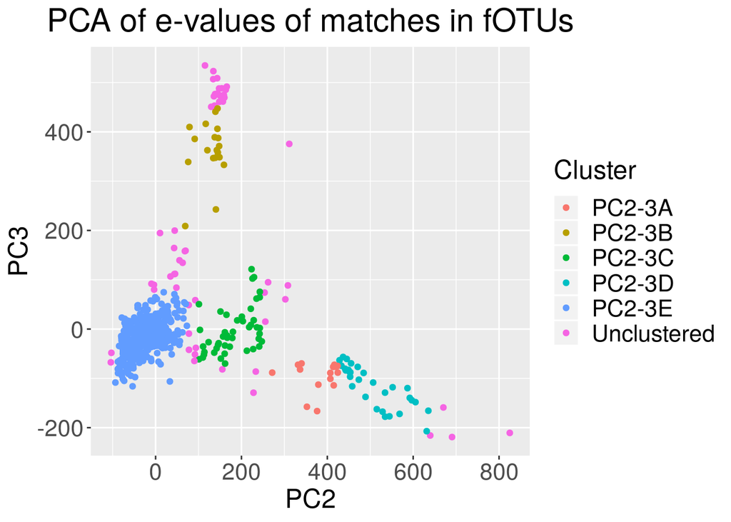

```r
ggsave(filename = "../visualisations/HMMsearch/pca_hmmsearch_max_PC1-2.png",
       device = png,
       width = figure_width,
       height = figure_height,
       units = "in",
       limitsize = FALSE,
       dpi = plot_resolution)

PC23s <- tibble(fOTUs = names(fOTUsHMM_pca$x[,1]),
              PC2 = unname(fOTUsHMM_pca$x[,2]),
              PC3 = unname(fOTUsHMM_pca$x[,3])) %>%
  mutate(Cluster = case_when(PC2 >= -100 & PC2 <= 75  & PC3 >= -150 & PC3 <= 80 ~ 'PC2-3E',
                             PC2 >= 100  & PC2 <= 250 & PC3 >= -80  & PC3 <= 125 ~ 'PC2-3C',
                             PC2 >= 250  & PC2 <= 425 & PC3 >= -200 & PC3 <= 0 ~ 'PC2-3A',
                             PC2 >= 400  & PC2 <= 650 & PC3 >= -210 & PC3 <= 80 ~ 'PC2-3D',
                             PC2 >= 0    & PC2 <= 200 & PC3 >= 200  & PC3 <= 450 ~ 'PC2-3B',
                             TRUE ~ 'Unclustered')) %>%
  mutate_at(4, as.factor)

title <- "PCA of e-values of matches in fOTUs"
qplot(PC2,
      PC3,
      data = PC23s,
      geom = c("point"),
      group = Cluster,
      color = Cluster,
      fill = Cluster) + ggtitle(title) +
  theme(plot.title = element_text(hjust = plot_title_justification,
                                  size  = plot_title_size),
        axis.title=element_text(  size  = axis_title_size)) +
  theme(legend.text=element_text( size  = legend_text_size)) +
  theme(legend.title=element_text(size  = legend_title_size)) +
  theme(axis.text=element_text(   size  = axis_text_size))
```

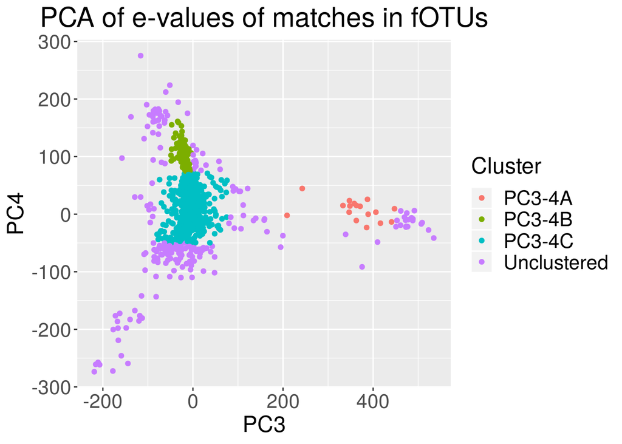

```r
ggsave(filename = "../visualisations/HMMsearch/pca_hmmsearch_max_PC2-3.png",
       device = png,
       width = figure_width,
       height = figure_height,
       units = "in",
       limitsize = FALSE,
       dpi = plot_resolution)

PC34s <- tibble(fOTUs = names(fOTUsHMM_pca$x[,1]),
              PC3 = unname(fOTUsHMM_pca$x[,3]),
              PC4 = unname(fOTUsHMM_pca$x[,4])) %>%
  mutate(Cluster = case_when(PC3 >= -80 & PC3 <= 80 & PC4 >= -50 & PC4 <= 75 ~ 'PC3-4C',
                             PC3 >= -50 & PC3 <= 0 & PC4 >= 75 & PC4 <= 175 ~ 'PC3-4B',
                             PC3 >= 200 & PC3 <= 450 & PC4 >= -25 & PC4 <= 50 ~ 'PC3-4A',
                             TRUE ~ 'Unclustered')) %>%
  mutate_at(4, as.factor)

title <- "PCA of e-values of matches in fOTUs"
qplot(PC3,
      PC4,
      data = PC34s,
      geom = c("point"),
      group = Cluster,
      color = Cluster,
      fill = Cluster) + ggtitle(title) +
  theme(plot.title = element_text(hjust = plot_title_justification,
                                  size  = plot_title_size),
        axis.title=element_text(  size  = axis_title_size)) +
  theme(legend.text=element_text( size  = legend_text_size)) +
  theme(legend.title=element_text(size  = legend_title_size)) +
  theme(axis.text=element_text(   size  = axis_text_size))
```

```r
ggsave(filename = "../visualisations/HMMsearch/pca_hmmsearch_max_PC3-4.png",
       device = png,
       width = figure_width,
       height = figure_height,
       units = "in",
       limitsize = FALSE,
       dpi = plot_resolution)
```

These PCA plots can be used to visually determine potential groupings.

```r
file_name <- "../visualisations/HMMsearch/ggbiplot_max_PC1-2.png"
png(filename = file_name,
    width = figure_width,
    height = figure_height)
ggbiplot(fOTUsHMM_pca,
         var.axes = F,
         choices = 1:2) +
  ggtitle("PCA of fOTU wise HMM data") +
  theme(plot.title = element_text(hjust = plot_title_justification,
                                  size = plot_title_size),
        axis.title=element_text(size = axis_title_size))
dev.off()
```

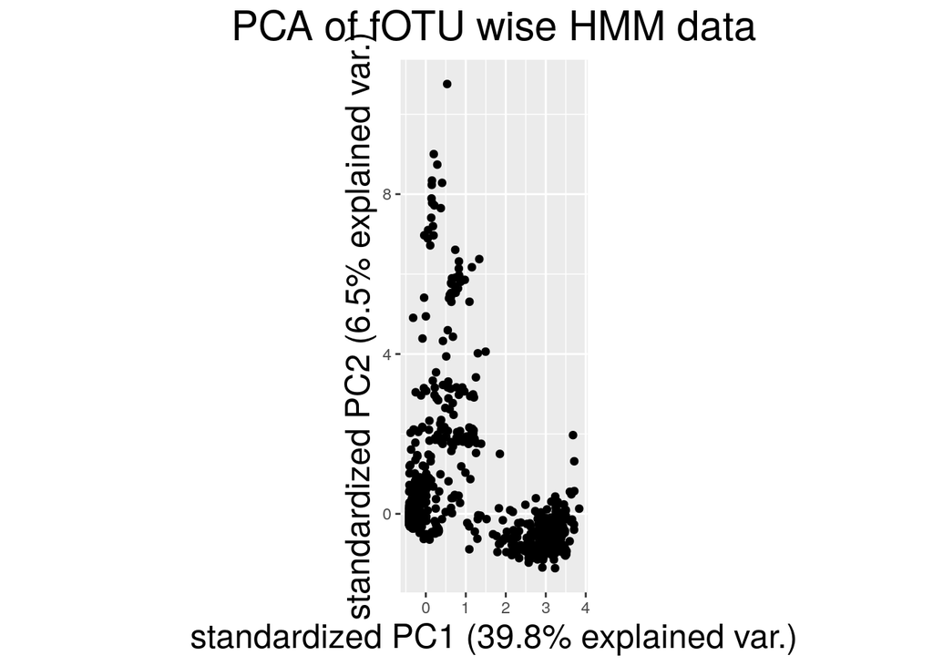

```r
ggbiplot(fOTUsHMM_pca,
         var.axes = F,
         choices = 1:2) +
  ggtitle("PCA of fOTU wise HMM data") +
  theme(plot.title = element_text(hjust = plot_title_justification,
                                  size = plot_title_size),
        axis.title=element_text(size = axis_title_size))
```

## 5.2 Heatmaps

```r
dim(fOTUsHMM_pca)
```

```r
prediction <- predict(fOTUsHMM_pca)[,1:20]
file_name <- "../visualisations/HMMsearch/heatmap_max_20_first_PCs.png"
png(filename = file_name)
heatmap(as.matrix(prediction))
dev.off()
```

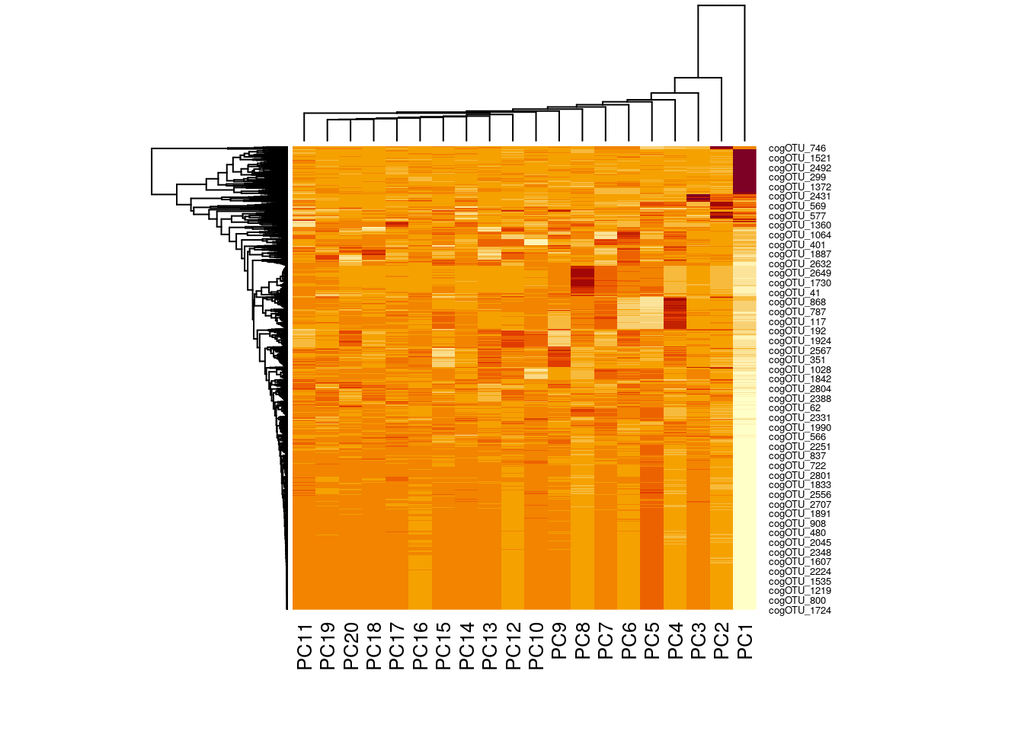

```r
heatmap(as.matrix(prediction))
```

```r
file_name <- "../visualisations/HMMsearch/heatmap_max_400_first_fOTUs.png"
png(filename = file_name)
heatmap(as.matrix(fOTUsHMM[,-1])[,1:400])
dev.off()
```

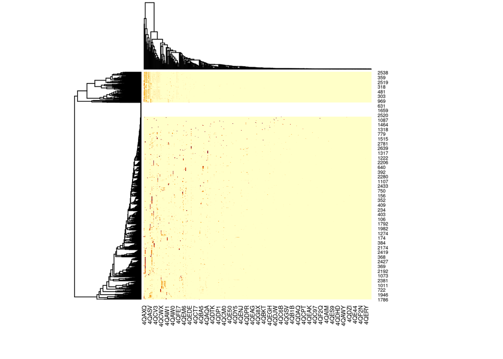

```r
heatmap(as.matrix(fOTUsHMM[,-1])[,1:400])
```

# 6 NMDS

Let’s perform non-metric multidimensional scaling:

```r
width <- dim(fOTUsHMM)[2]
ord <- metaMDS(fOTUsHMM[,2:width])
```

# 7 Save/Load R data

Save the data once again to speed-up things.

```r
#saveRDS(ord, file = "../analyses/HMMsearch/R_data/max_ord.rds")
ord <- readRDS(file = "../analyses/HMMsearch/R_data/max_ord.rds")
```

How well does the 2-D representation of multidimensional space represent the actual multidimensional space is done by using statistic called stress. Stress < 0.1 indicates that the 2-D representation is a good repreresentation of the multi-D space. Let’s check that out now:

```r
ord$stress
```

```
## [1] 0.05091335
```

This is quite low which is great! Let’s now plot out the relationship between the ordination dissimilarities and the distances in the ordination space:

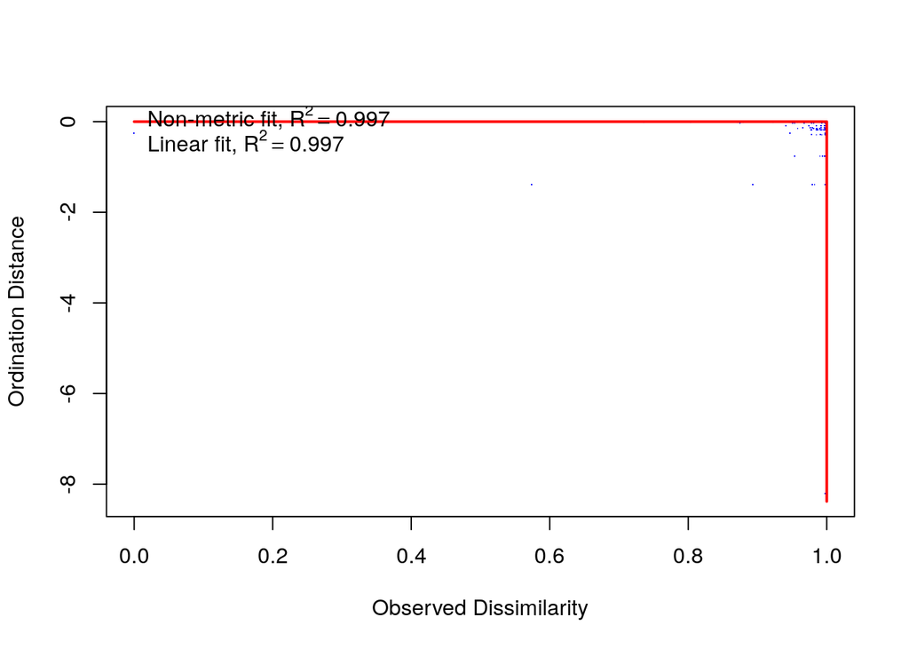

```r
stressplot(ord)
```

Observed dissimilarity of 1 means the fOTU doesn’t have any HMMs incommon with the others.

Let’s plot out the ordination space in 2-d:

```r
file_name <- "../visualisations/HMMsearch/nmds_ordiplot_all_data.png"
png(filename = file_name)
ordiplot(ord)
points(ord)
dev.off()
```

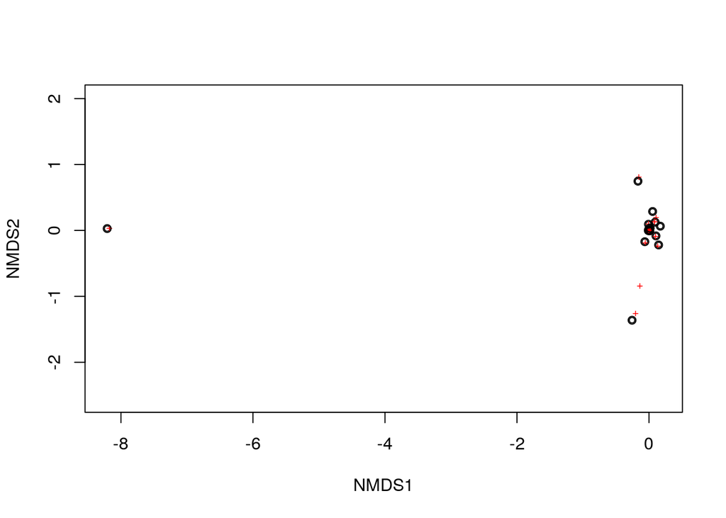

```r
ordiplot(ord)
points(ord)
```

# 8 Find and filter out the outlier(s)

These are just removed so that it’s easier to see the better the whole data.

```r
NMDS_points <- fOTUsHMM[-which(as_tibble(ord$points)$MDS1 < -2), ]
```

# 9 Rerun NMDS with outliers removed

Let’s perform non-metric multidimensional scaling again:

```r
width <- dim(NMDS_points)[2]
ord <- metaMDS(NMDS_points[,2:width],)
```

# 10 Save/Load R data

Save the data once again to speed-up things.

```r
#saveRDS(ord, file = "../analyses/HMMsearch/R_data/max_ord_outlier_filtered.rds")
ord <- readRDS(file = "../analyses/HMMsearch/R_data/max_ord_outlier_filtered.rds")
```

Here is the stress plot for this new NMDS:

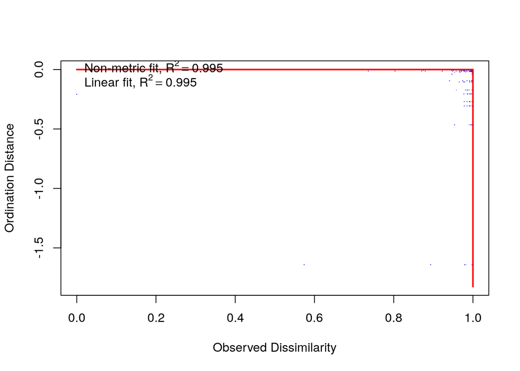

```r
stressplot(ord)
```

```r
file_name <- "../visualisations/HMMsearch/nmds_ordiplot_all_data_outlier_filtered.png"
png(filename = file_name)
ordiplot(ord)
points(ord)
dev.off()
```

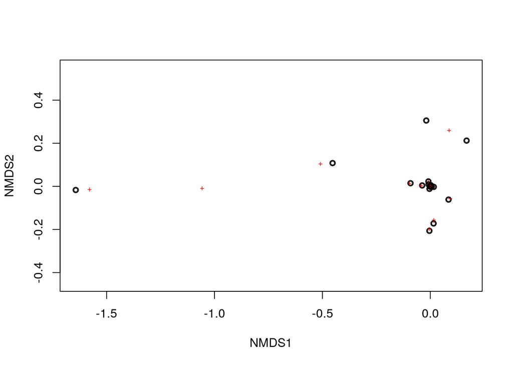

```r
ordiplot(ord)
points(ord)
```

# 11 Make a nicer figure of NMDS plot

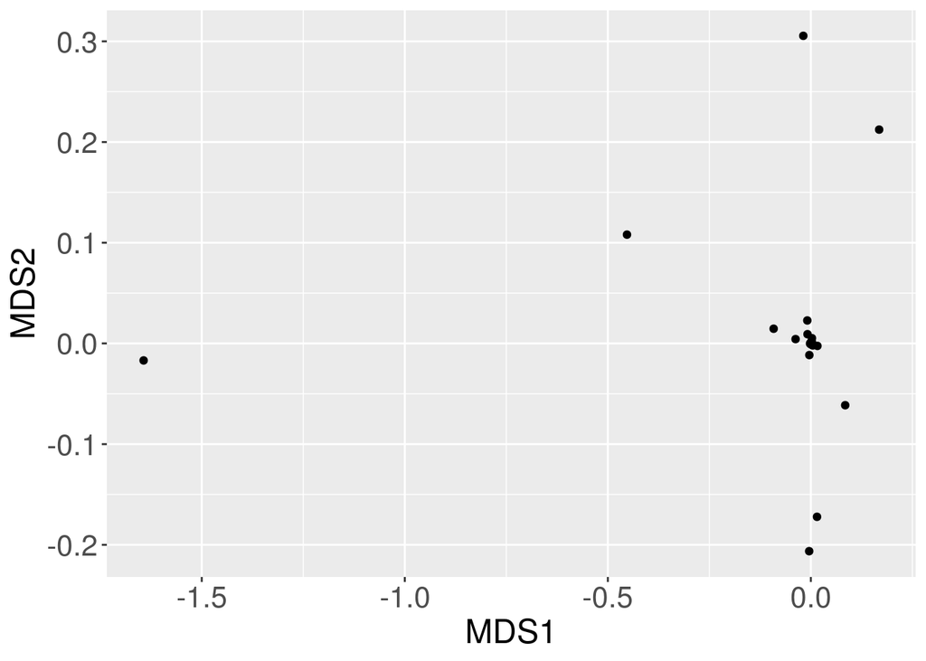

```r
NMDS_points <- as_tibble(ord[["points"]])

qplot(MDS1,
      MDS2,
      data = NMDS_points,
      geom = c("point")) +
  theme(plot.title = element_text(hjust = plot_title_justification,
                                  size  = plot_title_size),
        axis.title=element_text(  size  = axis_title_size)) +
  theme(axis.text=element_text(   size  = axis_text_size))
```

```r
path <- "../visualisations/HMMsearch/nmds_hmmsearch_max_all_data.png"
ggsave(filename = path,
       device = png,
       width = figure_width,
       height = figure_height,
       units = "in",
       limitsize = FALSE,
       dpi = plot_resolution)
```

# 12 Create lists of fOTUs of interest

## 12.1 PCA lists

Based on the previewing of PCA plots in 5.1 we can now manually curate a lists of fOTUs approximately based on clustering in them.

Let’s first create file names:

```r
# Path to files
path <- "../analyses/HMMsearch/lists_of_PCA_clusters/"

# Names of files
PC12a_filename <- paste(path,
                        "fOTU_max_PC1-and-2_x--100-to-0-and-y--50-to-+50.txt",
                        sep = "",
                        collapse = NULL)
PC12b_filename <- paste(path,
                        "fOTU_max_PC1-and-2_x-+200-to-+500-and-y--100-to-0.txt",
                        sep = "",
                        collapse = NULL)


PC23a_filename <- paste(path,
                       "fOTU_max_PC2-and-3_x--100-to-+75-and-y--150-to-+80.txt",
                       sep = "",
                       collapse = NULL)
PC23b_filename <- paste(path,
                       "fOTU_max_PC2-and-3_x-+100-to-+250-and-y--80-to-+125.txt",
                       sep = "",
                       collapse = NULL)
PC23c_filename <- paste(path,
                       "fOTU_max_PC2-and-3_x-+250-to-+425-and-y--200-to-0.txt",
                       sep = "",
                       collapse = NULL)
PC23d_filename <- paste(path,
                       "fOTU_max_PC2-and-3_x-+400-to-+650-and-y--210-to--80.txt",
                       sep = "",
                       collapse = NULL)
PC23e_filename <- paste(path,
                       "fOTU_max_PC2-and-3_x-0-to-+200-and-y-+200-to-+450.txt",
                       sep = "",
                       collapse = NULL)


PC34a_filename <- paste(path,
                       "fOTU_max_PC3-and-4_x--80-to-+80-and-y--50-to-+75.txt",
                       sep = "",
                       collapse = NULL)
PC34b_filename <- paste(path,
                       "fOTU_max_PC3-and-4_x--50-to-0-and-y-+75-to-+175.txt",
                       sep = "",
                       collapse = NULL)
PC34c_filename <- paste(path,
                       "fOTU_max_PC3-and-4_x-+200-to-+450-and-y--25-to-+50.txt",
                       sep = "",
                       collapse = NULL)
```

and then we’ll filter tibbles based on their coordinates with a simple function:

```r
# This function filters a tibble based on given limit values
filterator <- function(data,
                       x_low = -9999,
                       x_high = 9999,
                       y_low = -9999,
                       y_high = 9999){
  data %>%
    filter(data[,2] > x_low & data[,2] < x_high & data[,3] > y_low & data[,3] < y_high) %>%
    select(1)
}
```

and the actual filtering:

```r
PC12_cluster1 <- filterator(PC12s,-100,0,-50,50)
PC12_cluster2 <- filterator(PC12s,200,500,-100,0)

PC23_cluster1 <- filterator(PC23s,-100,75,-150,80)
PC23_cluster2 <- filterator(PC23s,100,250,-80,125)
PC23_cluster3 <- filterator(PC23s,250,425,-200,0)
PC23_cluster4 <- filterator(PC23s,400,650,-210,80)
PC23_cluster5 <- filterator(PC23s,0,200,200,450)

PC34_cluster1 <- filterator(PC34s,-80,80,-50,75)
PC34_cluster2 <- filterator(PC34s,-50,0,75,175)
PC34_cluster3 <- filterator(PC34s,200,450,-25,50)
```

Lastly, we’ll just write the files:

```r
# PC1-PC2 manually curated clusters
write_delim(PC12_cluster1,
            PC12a_filename,
            delim = "",
            na = "NA",
            append = FALSE,
            col_names = FALSE,
            quote_escape = "double")
write_delim(PC12_cluster2,
            PC12b_filename,
            delim = "",
            na = "NA",
            append = FALSE,
            col_names = FALSE,
            quote_escape = "double")

# PC2-PC3 manually curated clusters
write_delim(PC23_cluster1,
            PC23a_filename,
            delim = "",
            na = "NA",
            append = FALSE,
            col_names = FALSE,
            quote_escape = "double")
write_delim(PC23_cluster2,
            PC23b_filename,
            delim = "",
            na = "NA",
            append = FALSE,
            col_names = FALSE,
            quote_escape = "double")
write_delim(PC23_cluster3,
            PC23c_filename,
            delim = "",
            na = "NA",
            append = FALSE,
            col_names = FALSE,
            quote_escape = "double")
write_delim(PC23_cluster4,
            PC23d_filename,
            delim = "",
            na = "NA",
            append = FALSE,
            col_names = FALSE,
            quote_escape = "double")
write_delim(PC23_cluster5,
            PC23e_filename,
            delim = "",
            na = "NA",
            append = FALSE,
            col_names = FALSE,
            quote_escape = "double")

# PC3-PC4 manually curated clusters
write_delim(PC34_cluster1,
            PC34a_filename,
            delim = "",
            na = "NA",
            append = FALSE,
            col_names = FALSE,
            quote_escape = "double")
write_delim(PC34_cluster2,
            PC34b_filename,
            delim = "",
            na = "NA",
            append = FALSE,
            col_names = FALSE,
            quote_escape = "double")
write_delim(PC34_cluster3,
            PC34c_filename,
            delim = "",
            na = "NA",
            append = FALSE,
            col_names = FALSE,
            quote_escape = "double")
```

## 12.2 NMDS lists

Let’s first create file names for the putative clusters:

```r
# Path to files
path <- "../analyses/HMMsearch/lists_of_clusters/"

# Names of files
NMDSa_filename <- paste(path,
                       "fOTU_max_NMDS_x--10-to--7.txt",
                       sep = "",
                       collapse = NULL)
NMDSb_filename <- paste(path,
                       "fOTU_max_NMDS_x--1-to--0_2.txt",
                       sep = "",
                       collapse = NULL)
NMDSc_filename <- paste(path,
                       "fOTU_max_NMDS_x--0_2-to--0.05txt",
                       sep = "",
                       collapse = NULL)
NMDSd_filename <- paste(path,
                       "fOTU_max_NMDS_x--0_02-to-0.txt",
                       sep = "",
                       collapse = NULL)
NMDSe_filename <- paste(path,
                       "fOTU_max_NMDS_x-0-to-+0_01.txt",
                       sep = "",
                       collapse = NULL)
NMDSf_filename <- paste(path,
                       "fOTU_max_NMDS_x-+0_01-to-+0_02.txt",
                       sep = "",
                       collapse = NULL)
NMDSg_filename <- paste(path,
                       "fOTU_max_NMDS_x-+0_05-to-+9999.txt",
                       sep = "",
                       collapse = NULL)
```

Now we need to have a data frame with 3 columns, first of which contains the fOTU names. This so because then the already made function `filterator`’s indexing is correct.

```r
unfiltered <- as_tibble(ord$points)
# Prepend the fOTU_names before first column
unfiltered <- cbind(select(fOTUsHMM,1),
                    unfiltered)
```

and execute the actual filtering:

```r
# The outlier
NMDS_cluster1 <- filterator(unfiltered,
                            x_low = -10,
                            x_high = -7)
# And the rest
NMDS_cluster2 <- filterator(unfiltered,
                            x_low = -1,
                            x_high = -0.2)
NMDS_cluster3 <- filterator(unfiltered,
                            x_low = -0.2,
                            x_high = -0.05)
NMDS_cluster4 <- filterator(unfiltered,
                            x_low = -0.02,
                            x_high = 0)
NMDS_cluster5 <- filterator(unfiltered,
                            x_low = 0,
                            x_high = 0.01)
NMDS_cluster6 <- filterator(unfiltered,
                            x_low = 0.01,
                            x_high = 0.02)
NMDS_cluster7 <- filterator(unfiltered,
                            x_low = 0.05)
```

Lastly, we’ll just write the cluster list files:

```r
write_delim(NMDS_cluster1,
            NMDSa_filename,
            delim = "",
            na = "NA",
            append = FALSE,
            col_names = FALSE,
            quote_escape = "double")
write_delim(NMDS_cluster2,
            NMDSb_filename,
            delim = "",
            na = "NA",
            append = FALSE,
            col_names = FALSE,
            quote_escape = "double")
write_delim(NMDS_cluster3,
            NMDSc_filename,
            delim = "",
            na = "NA",
            append = FALSE,
            col_names = FALSE,
            quote_escape = "double")
write_delim(NMDS_cluster4,
            NMDSd_filename,
            delim = "",
            na = "NA",
            append = FALSE,
            col_names = FALSE,
            quote_escape = "double")
write_delim(NMDS_cluster5,
            NMDSe_filename,
            delim = "",
            na = "NA",
            append = FALSE,
            col_names = FALSE,
            quote_escape = "double")
write_delim(NMDS_cluster6,
            NMDSf_filename,
            delim = "",
            na = "NA",
            append = FALSE,
            col_names = FALSE,
            quote_escape = "double")
write_delim(NMDS_cluster7,
            NMDSg_filename,
            delim = "",
            na = "NA",
            append = FALSE,
            col_names = FALSE,
            quote_escape = "double")
```

# 14 References